# (Visualizing and Analysing the Data Set of Ford Gobike System Data)

## by Turki Ali

### Table Contents:

1) Introduction of the topic and about dataset

2) Preliminary wrangling

3) Data Assessment

4) Cleaning

5) Univariate Exploration and Analysis

6) Bivariate Exploration and Analysis

7) Multivariate Exploration and Analysis

8) Conclusions

### Introduction:

Ford GoBike system data is the Bay Area's new bike share system, with thousands of public bikes for use across San Francisco, East Bay and San Jose. Renting Bikes is designed with convenience in mind. it’s a fun and affordable way to get around town.It aslo offers Single Ride is 2 dollars per day which is great for one way trip, Monthly Memberships is 15 dollars per month for its good deal for locals and Access Pass for 10 dollars which is perfect for exploring.

### About Dataset:

I chose Ford GoBike System Data as my source data. This data set includes information about individual rides made in a bike-sharing system.Multiple data files will need to be joined together if a full year’s coverage is desired. The features included in the dataset : Trip Duration (seconds) , Start Time and Date , End Time and Date , Start Station ID , Start Station Name , Start Station Latitude , Start Station Longitude , End Station ID , End Station Name, End Station Latitude , End Station Longitude , Bike ID , User Type (Subscriber or Customer – “Subscriber” = Member or “Customer” = Casual) , Member Year of Birth, Member Gender

### Part 1:Preliminary Data Wrangling

```python
# import all packages and set plots to be embedded inline
from requests import get
import pandas as pd
import numpy as np
import matplotlib
from matplotlib import pyplot as plt
import matplotlib.ticker as tick
import seaborn as sns
import datetime
import glob
import os
import math
import warnings
warnings.filterwarnings('ignore')
from IPython.display import Image
%matplotlib inline
```

```python
# Load dataset
df= pd.read_csv('ford_bike_data.csv')
```

```python
df.head()
```

|  | duration_sec | start_time | end_time | start_station_id | start_station_name | start_station_latitude | start_station_longitude | end_station_id | end_station_name | end_station_latitude | end_station_longitude | bike_id | user_type | member_birth_year | member_gender | bike_share_for_all_trip |
| --- | --- | --- | --- | --- | --- | --- | --- | --- | --- | --- | --- | --- | --- | --- | --- | --- |
| 0 | 50305 | 2019-04-30 22:33:55.1550 | 2019-05-01 12:32:20.4540 | 368.0 | Myrtle St at Polk St | 37.785434 | -122.419622 | 324.0 | Union Square (Powell St at Post St) | 37.788300 | -122.408531 | 2749 | Subscriber | 1989.0 | Female | No |
| 1 | 53725 | 2019-04-30 20:43:41.6320 | 2019-05-01 11:39:06.9170 | 246.0 | Berkeley Civic Center | 37.869060 | -122.270556 | 241.0 | Ashby BART Station | 37.852477 | -122.270213 | 2608 | Customer | NaN | NaN | No |
| 2 | 78072 | 2019-04-30 10:32:46.4890 | 2019-05-01 08:13:58.9750 | 64.0 | 5th St at Brannan St | 37.776754 | -122.399018 | 64.0 | 5th St at Brannan St | 37.776754 | -122.399018 | 258 | Subscriber | 1993.0 | Male | No |
| 3 | 78969 | 2019-04-30 10:00:51.5500 | 2019-05-01 07:57:01.2620 | 67.0 | San Francisco Caltrain Station 2 (Townsend St... | 37.776639 | -122.395526 | 89.0 | Division St at Potrero Ave | 37.769218 | -122.407646 | 1974 | Subscriber | 1972.0 | Male | No |
| 4 | 1128 | 2019-04-30 23:59:04.7390 | 2019-05-01 00:17:53.0910 | 124.0 | 19th St at Florida St | 37.760447 | -122.410807 | 5.0 | Powell St BART Station (Market St at 5th St) | 37.783899 | -122.408445 | 877 | Subscriber | 1973.0 | Male | No |

### Part2:Data Assessment

```python
df.info()
```

```
<class 'pandas.core.frame.DataFrame'>
RangeIndex: 239111 entries, 0 to 239110
Data columns (total 16 columns):
 #   Column                   Non-Null Count   Dtype
---  ------                   --------------   -----
 0   duration_sec             239111 non-null  int64
 1   start_time               239111 non-null  object
 2   end_time                 239111 non-null  object
 3   start_station_id         239047 non-null  float64
 4   start_station_name       239047 non-null  object
 5   start_station_latitude   239111 non-null  float64
 6   start_station_longitude  239111 non-null  float64
 7   end_station_id           239047 non-null  float64
 8   end_station_name         239047 non-null  object
 9   end_station_latitude     239111 non-null  float64
 10  end_station_longitude    239111 non-null  float64
 11  bike_id                  239111 non-null  int64
 12  user_type                239111 non-null  object
 13  member_birth_year        227912 non-null  float64
 14  member_gender            227912 non-null  object
 15  bike_share_for_all_trip  239111 non-null  object
dtypes: float64(7), int64(2), object(7)
memory usage: 29.2+ MB
```

```python
df.sample(15)
```

|  | duration_sec | start_time | end_time | start_station_id | start_station_name | start_station_latitude | start_station_longitude | end_station_id | end_station_name | end_station_latitude | end_station_longitude | bike_id | user_type | member_birth_year | member_gender | bike_share_for_all_trip |
| --- | --- | --- | --- | --- | --- | --- | --- | --- | --- | --- | --- | --- | --- | --- | --- | --- |
| 43121 | 270 | 2019-04-24 09:24:12.4090 | 2019-04-24 09:28:42.8270 | 108.0 | 16th St Mission BART | 37.764710 | -122.419957 | 100.0 | Bryant St at 15th St | 37.767100 | -122.410662 | 3284 | Subscriber | 1990.0 | Male | No |
| 200502 | 848 | 2019-04-04 18:26:56.7770 | 2019-04-04 18:41:04.8740 | 5.0 | Powell St BART Station (Market St at 5th St) | 37.783899 | -122.408445 | 71.0 | Broderick St at Oak St | 37.773063 | -122.439078 | 6803 | Subscriber | 1990.0 | Male | No |
| 184418 | 627 | 2019-04-06 17:14:45.6650 | 2019-04-06 17:25:13.0910 | 3.0 | Powell St BART Station (Market St at 4th St) | 37.786375 | -122.404904 | 3.0 | Powell St BART Station (Market St at 4th St) | 37.786375 | -122.404904 | 5828 | Subscriber | 1993.0 | Male | No |
| 194492 | 838 | 2019-04-05 14:54:16.3210 | 2019-04-05 15:08:14.8570 | 252.0 | Channing Way at Shattuck Ave | 37.865847 | -122.267443 | 171.0 | Rockridge BART Station | 37.844279 | -122.251900 | 5745 | Customer | 1997.0 | Male | No |
| 79955 | 768 | 2019-04-18 09:59:48.0940 | 2019-04-18 10:12:37.0870 | 60.0 | 8th St at Ringold St | 37.774520 | -122.409449 | 22.0 | Howard St at Beale St | 37.789756 | -122.394643 | 3060 | Subscriber | 1995.0 | Female | No |
| 152231 | 253 | 2019-04-09 22:17:19.2430 | 2019-04-09 22:21:33.0520 | 343.0 | Bryant St at 2nd St | 37.783172 | -122.393572 | 21.0 | Montgomery St BART Station (Market St at 2nd St) | 37.789625 | -122.400811 | 963 | Subscriber | 1997.0 | Male | No |
| 8645 | 254 | 2019-04-29 19:03:53.2280 | 2019-04-29 19:08:07.5540 | 176.0 | MacArthur BART Station | 37.828410 | -122.266315 | 211.0 | Broadway at 40th St | 37.827757 | -122.256716 | 1730 | Subscriber | NaN | NaN | No |
| 222816 | 457 | 2019-04-02 18:02:41.9030 | 2019-04-02 18:10:19.6020 | 30.0 | San Francisco Caltrain (Townsend St at 4th St) | 37.776598 | -122.395282 | 60.0 | 8th St at Ringold St | 37.774520 | -122.409449 | 6964 | Subscriber | 1993.0 | Male | Yes |
| 1909 | 1645 | 2019-04-30 17:39:39.3390 | 2019-04-30 18:07:05.2980 | 15.0 | San Francisco Ferry Building (Harry Bridges Pl... | 37.795392 | -122.394203 | 399.0 | Bay St at Fillmore St | 37.802636 | -122.436289 | 3189 | Subscriber | 1992.0 | Male | No |
| 119377 | 297 | 2019-04-12 17:08:26.6620 | 2019-04-12 17:13:23.8120 | 44.0 | Civic Center/UN Plaza BART Station (Market St ... | 37.781074 | -122.411738 | 370.0 | Jones St at Post St | 37.787327 | -122.413278 | 5310 | Subscriber | 1985.0 | Male | No |
| 36211 | 237 | 2019-04-25 08:39:27.7430 | 2019-04-25 08:43:25.3780 | 114.0 | Rhode Island St at 17th St | 37.764478 | -122.402570 | 90.0 | Townsend St at 7th St | 37.771058 | -122.402717 | 3498 | Customer | 1982.0 | Male | No |
| 234832 | 510 | 2019-04-01 12:38:56.4110 | 2019-04-01 12:47:27.0690 | 58.0 | Market St at 10th St | 37.776619 | -122.417385 | 21.0 | Montgomery St BART Station (Market St at 2nd St) | 37.789625 | -122.400811 | 4318 | Subscriber | 2000.0 | Female | No |
| 4568 | 676 | 2019-04-30 11:44:10.2800 | 2019-04-30 11:55:27.2530 | 31.0 | Raymond Kimbell Playground | 37.783813 | -122.434559 | 60.0 | 8th St at Ringold St | 37.774520 | -122.409449 | 824 | Subscriber | NaN | NaN | No |
| 146971 | 1023 | 2019-04-10 12:37:25.7440 | 2019-04-10 12:54:29.1420 | 365.0 | Turk St at Fillmore St | 37.780450 | -122.431946 | 17.0 | Embarcadero BART Station (Beale St at Market St) | 37.792251 | -122.397086 | 5845 | Customer | 1994.0 | Male | No |
| 189891 | 718 | 2019-04-05 20:44:33.7900 | 2019-04-05 20:56:32.4130 | 60.0 | 8th St at Ringold St | 37.774520 | -122.409449 | 97.0 | 14th St at Mission St | 37.768265 | -122.420110 | 7050 | Subscriber | 1983.0 | Male | No |

```python
# Check if duplicates exist
df.duplicated().sum()
```

```
0
```

```python
# View descriptive statistics of the dataframe
df.describe()
```

|  | duration_sec | start_station_id | start_station_latitude | start_station_longitude | end_station_id | end_station_latitude | end_station_longitude | bike_id | member_birth_year |
| --- | --- | --- | --- | --- | --- | --- | --- | --- | --- |
| count | 239111.000000 | 239047.000000 | 239111.000000 | 239111.000000 | 239047.000000 | 239111.000000 | 239111.000000 | 239111.000000 | 227912.000000 |
| mean | 802.671199 | 141.836538 | 37.769536 | -122.352503 | 140.838099 | 37.766996 | -122.343420 | 3666.956493 | 1984.863250 |
| std | 1990.006091 | 116.289776 | 0.127698 | 0.277088 | 116.386168 | 0.343083 | 1.068144 | 2180.717333 | 9.953144 |
| min | 61.000000 | 3.000000 | 0.000000 | -122.453704 | 3.000000 | 0.000000 | -122.453704 | 11.000000 | 1878.000000 |
| 25% | 349.000000 | 47.000000 | 37.770083 | -122.413004 | 44.000000 | 37.770407 | -122.411738 | 1720.000000 | 1980.000000 |
| 50% | 558.000000 | 104.000000 | 37.780760 | -122.398285 | 102.000000 | 37.780955 | -122.397437 | 3471.000000 | 1987.000000 |
| 75% | 876.000000 | 240.000000 | 37.797280 | -122.291209 | 239.000000 | 37.797320 | -122.291376 | 5749.000000 | 1992.000000 |
| max | 86114.000000 | 420.000000 | 37.880222 | 0.000000 | 420.000000 | 37.880222 | 0.000000 | 7108.000000 | 2001.000000 |

### Quality issues

1) start time and end time are objects change to timestamps

2) user type, bike_share_for_all_trip and gender change to category

3) bike id, start_station_id, end_station_id can be set as object

4) get month, day, hour, weekday columns to further analyze the dataset

5) calculate the distance for rides

6) member birth year has dates prior to 1900

7) calculate the age of the user

### Part 3: Cleaning Data:

```python
#create copy of original dataframe
df_clean = df.copy()
```

### Define:

Change Datatypes accordingly as mentioned in Quality Issues section

### Code:

```python
# set start_time and end_time to timestamps
df_clean.start_time = pd.to_datetime(df_clean.start_time)
df_clean.end_time = pd.to_datetime(df_clean.end_time)
```

```python
# set user type, gender and bike_share_for_all_trip to category
df_clean.user_type = df_clean.user_type.astype('category')
df_clean.member_gender = df_clean.member_gender.astype('category')
df_clean.bike_share_for_all_trip = df_clean.bike_share_for_all_trip.astype('category')
```

```python
# set bike id, start_station_id, end_station_id to object
df_clean.bike_id = df_clean.bike_id.astype(str)
df_clean.start_station_id = df_clean.bike_id.astype(str)
df_clean.end_station_id = df_clean.bike_id.astype(str)
```

### Test:

```python
df_clean.info(verbose=True, null_counts=True)
```

```
<class 'pandas.core.frame.DataFrame'>
RangeIndex: 239111 entries, 0 to 239110
Data columns (total 16 columns):
 #   Column                   Non-Null Count   Dtype
---  ------                   --------------   -----
 0   duration_sec             239111 non-null  int64
 1   start_time               239111 non-null  datetime64[ns]
 2   end_time                 239111 non-null  datetime64[ns]
 3   start_station_id         239111 non-null  object
 4   start_station_name       239047 non-null  object
 5   start_station_latitude   239111 non-null  float64
 6   start_station_longitude  239111 non-null  float64
 7   end_station_id           239111 non-null  object
 8   end_station_name         239047 non-null  object
 9   end_station_latitude     239111 non-null  float64
 10  end_station_longitude    239111 non-null  float64
 11  bike_id                  239111 non-null  object
 12  user_type                239111 non-null  category
 13  member_birth_year        227912 non-null  float64
 14  member_gender            227912 non-null  category
 15  bike_share_for_all_trip  239111 non-null  category
dtypes: category(3), datetime64[ns](2), float64(5), int64(1), object(5)
memory usage: 24.4+ MB
```

### Define:

Calculate age of member

### Code:

```python
# substract the member_birth_year from the current year=2020
df_clean['member_age'] = 2020-df_clean['member_birth_year']
```

### Test:

```python
df_clean.head()
```

|  | duration_sec | start_time | end_time | start_station_id | start_station_name | start_station_latitude | start_station_longitude | end_station_id | end_station_name | end_station_latitude | end_station_longitude | bike_id | user_type | member_birth_year | member_gender | bike_share_for_all_trip | member_age |
| --- | --- | --- | --- | --- | --- | --- | --- | --- | --- | --- | --- | --- | --- | --- | --- | --- | --- |
| 0 | 50305 | 2019-04-30 22:33:55.155 | 2019-05-01 12:32:20.454 | 2749 | Myrtle St at Polk St | 37.785434 | -122.419622 | 2749 | Union Square (Powell St at Post St) | 37.788300 | -122.408531 | 2749 | Subscriber | 1989.0 | Female | No | 31.0 |
| 1 | 53725 | 2019-04-30 20:43:41.632 | 2019-05-01 11:39:06.917 | 2608 | Berkeley Civic Center | 37.869060 | -122.270556 | 2608 | Ashby BART Station | 37.852477 | -122.270213 | 2608 | Customer | NaN | NaN | No | NaN |
| 2 | 78072 | 2019-04-30 10:32:46.489 | 2019-05-01 08:13:58.975 | 258 | 5th St at Brannan St | 37.776754 | -122.399018 | 258 | 5th St at Brannan St | 37.776754 | -122.399018 | 258 | Subscriber | 1993.0 | Male | No | 27.0 |
| 3 | 78969 | 2019-04-30 10:00:51.550 | 2019-05-01 07:57:01.262 | 1974 | San Francisco Caltrain Station 2 (Townsend St... | 37.776639 | -122.395526 | 1974 | Division St at Potrero Ave | 37.769218 | -122.407646 | 1974 | Subscriber | 1972.0 | Male | No | 48.0 |
| 4 | 1128 | 2019-04-30 23:59:04.739 | 2019-05-01 00:17:53.091 | 877 | 19th St at Florida St | 37.760447 | -122.410807 | 877 | Powell St BART Station (Market St at 5th St) | 37.783899 | -122.408445 | 877 | Subscriber | 1973.0 | Male | No | 47.0 |

### Define:

Extract and Create new columns Monthname,Month,Weekday,Day of the week and hour from start_time column

### Code:

```python
# extract month name from start_time column
df_clean['st_month_name']=df_clean['start_time'].dt.strftime('%B')
```

```python
# extract month number from start_time column
df_clean['start_time_month']=df_clean['start_time'].dt.month.astype(int)
```

```python
# extract weekdays from start_time column
df_clean['start_time_weekday']=df_clean['start_time'].dt.strftime('%a')
```

```python
# extract day from start_time column
df_clean['start_time_day']=df_clean['start_time'].dt.day.astype(int)
```

```python
# extract hour from start_time column
df_clean['start_time_hour']=df_clean['start_time'].dt.hour
```

```python
df_clean.rename(columns={'start_time_month':'st_month',
                          'start_time_weekday':'st_weekday',
                          'start_time_day':'st_day',
                          'start_time_hour':'st_hour'},
                 inplace=True)
```

### Test:

```python
df_clean.info()
```

```
<class 'pandas.core.frame.DataFrame'>
RangeIndex: 239111 entries, 0 to 239110
Data columns (total 22 columns):
 #   Column                   Non-Null Count   Dtype
---  ------                   --------------   -----
 0   duration_sec             239111 non-null  int64
 1   start_time               239111 non-null  datetime64[ns]
 2   end_time                 239111 non-null  datetime64[ns]
 3   start_station_id         239111 non-null  object
 4   start_station_name       239047 non-null  object
 5   start_station_latitude   239111 non-null  float64
 6   start_station_longitude  239111 non-null  float64
 7   end_station_id           239111 non-null  object
 8   end_station_name         239047 non-null  object
 9   end_station_latitude     239111 non-null  float64
 10  end_station_longitude    239111 non-null  float64
 11  bike_id                  239111 non-null  object
 12  user_type                239111 non-null  category
 13  member_birth_year        227912 non-null  float64
 14  member_gender            227912 non-null  category
 15  bike_share_for_all_trip  239111 non-null  category
 16  member_age               227912 non-null  float64
 17  st_month_name            239111 non-null  object
 18  st_month                 239111 non-null  int32
 19  st_weekday               239111 non-null  object
 20  st_day                   239111 non-null  int32
 21  st_hour                  239111 non-null  int64
dtypes: category(3), datetime64[ns](2), float64(6), int32(2), int64(2), object(7)
memory usage: 33.5+ MB
```

```python
df_clean.head(10)
```

|  | duration_sec | start_time | end_time | start_station_id | start_station_name | start_station_latitude | start_station_longitude | end_station_id | end_station_name | end_station_latitude | ... | user_type | member_birth_year | member_gender | bike_share_for_all_trip | member_age | st_month_name | st_month | st_weekday | st_day | st_hour |
| --- | --- | --- | --- | --- | --- | --- | --- | --- | --- | --- | --- | --- | --- | --- | --- | --- | --- | --- | --- | --- | --- |
| 0 | 50305 | 2019-04-30 22:33:55.155 | 2019-05-01 12:32:20.454 | 2749 | Myrtle St at Polk St | 37.785434 | -122.419622 | 2749 | Union Square (Powell St at Post St) | 37.788300 | ... | Subscriber | 1989.0 | Female | No | 31.0 | April | 4 | Tue | 30 | 22 |
| 1 | 53725 | 2019-04-30 20:43:41.632 | 2019-05-01 11:39:06.917 | 2608 | Berkeley Civic Center | 37.869060 | -122.270556 | 2608 | Ashby BART Station | 37.852477 | ... | Customer | NaN | NaN | No | NaN | April | 4 | Tue | 30 | 20 |
| 2 | 78072 | 2019-04-30 10:32:46.489 | 2019-05-01 08:13:58.975 | 258 | 5th St at Brannan St | 37.776754 | -122.399018 | 258 | 5th St at Brannan St | 37.776754 | ... | Subscriber | 1993.0 | Male | No | 27.0 | April | 4 | Tue | 30 | 10 |
| 3 | 78969 | 2019-04-30 10:00:51.550 | 2019-05-01 07:57:01.262 | 1974 | San Francisco Caltrain Station 2 (Townsend St... | 37.776639 | -122.395526 | 1974 | Division St at Potrero Ave | 37.769218 | ... | Subscriber | 1972.0 | Male | No | 48.0 | April | 4 | Tue | 30 | 10 |
| 4 | 1128 | 2019-04-30 23:59:04.739 | 2019-05-01 00:17:53.091 | 877 | 19th St at Florida St | 37.760447 | -122.410807 | 877 | Powell St BART Station (Market St at 5th St) | 37.783899 | ... | Subscriber | 1973.0 | Male | No | 47.0 | April | 4 | Tue | 30 | 23 |
| 5 | 1388 | 2019-04-30 23:53:05.982 | 2019-05-01 00:16:14.313 | 3234 | Bancroft Way at College Ave | 37.869360 | -122.254337 | 3234 | Fulton St at Bancroft Way | 37.867789 | ... | Customer | 1997.0 | Male | No | 23.0 | April | 4 | Tue | 30 | 23 |
| 6 | 920 | 2019-04-30 23:57:56.340 | 2019-05-01 00:13:16.454 | 3262 | Washington St at 8th St | 37.800754 | -122.274894 | 3262 | San Pablo Ave at MLK Jr Way | 37.811351 | ... | Subscriber | 1976.0 | Male | Yes | 44.0 | April | 4 | Tue | 30 | 23 |
| 7 | 725 | 2019-04-30 23:56:11.219 | 2019-05-01 00:08:16.915 | 2706 | Civic Center/UN Plaza BART Station (Market St ... | 37.781074 | -122.411738 | 2706 | Mission Playground | 37.759210 | ... | Customer | 1973.0 | Male | No | 47.0 | April | 4 | Tue | 30 | 23 |
| 8 | 488 | 2019-04-30 23:59:00.660 | 2019-05-01 00:07:08.975 | 860 | Montgomery St BART Station (Market St at 2nd St) | 37.789625 | -122.400811 | 860 | 5th St at Brannan St | 37.776754 | ... | Subscriber | 1986.0 | Male | No | 34.0 | April | 4 | Tue | 30 | 23 |
| 9 | 792 | 2019-04-30 23:53:37.604 | 2019-05-01 00:06:50.405 | 896 | The Embarcadero at Bryant St | 37.787168 | -122.388098 | 896 | Esprit Park | 37.761634 | ... | Subscriber | 1995.0 | Male | No | 25.0 | April | 4 | Tue | 30 | 23 |

10 rows × 22 columns

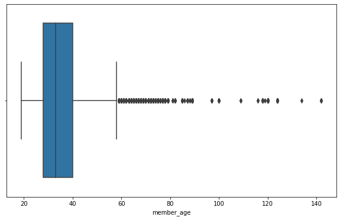

```python
# code for the age boxplot

plt.figure(figsize = [10, 6])
base_color = sns.color_palette()[0]

sns.boxplot(data=df_clean, x='member_age', color=base_color);
```

```python
df_clean.member_age.mean()
```

```
35.136750149180386
```

```python
df_clean.member_age.describe(percentiles = [ .95])
```

```
count    227912.000000
mean         35.136750
std           9.953144
min          19.000000
50%          33.000000
95%          55.000000
max         142.000000
Name: member_age, dtype: float64
```

### Define:

Remove Age outliers that are greater than 60. As mentioned in Quality Issues section, because in the dataset we have customers with birth year before 1900 which is over 100 years. For my analysis to keep it simple I consider members age less than 60

### Code:

```python
# Set member_age <= 60, it automatically removes null values
df_clean = df_clean.query('member_age <=60')
```

```python
# change age and birth year to integer
df_clean.member_age = df_clean.member_age.astype(int)
df_clean.member_birth_year = df_clean.member_birth_year.astype(int)
```

### Test

```python
df_clean.head(15)
```

|  | duration_sec | start_time | end_time | start_station_id | start_station_name | start_station_latitude | start_station_longitude | end_station_id | end_station_name | end_station_latitude | ... | user_type | member_birth_year | member_gender | bike_share_for_all_trip | member_age | st_month_name | st_month | st_weekday | st_day | st_hour |
| --- | --- | --- | --- | --- | --- | --- | --- | --- | --- | --- | --- | --- | --- | --- | --- | --- | --- | --- | --- | --- | --- |
| 0 | 50305 | 2019-04-30 22:33:55.155 | 2019-05-01 12:32:20.454 | 2749 | Myrtle St at Polk St | 37.785434 | -122.419622 | 2749 | Union Square (Powell St at Post St) | 37.788300 | ... | Subscriber | 1989 | Female | No | 31 | April | 4 | Tue | 30 | 22 |
| 2 | 78072 | 2019-04-30 10:32:46.489 | 2019-05-01 08:13:58.975 | 258 | 5th St at Brannan St | 37.776754 | -122.399018 | 258 | 5th St at Brannan St | 37.776754 | ... | Subscriber | 1993 | Male | No | 27 | April | 4 | Tue | 30 | 10 |
| 3 | 78969 | 2019-04-30 10:00:51.550 | 2019-05-01 07:57:01.262 | 1974 | San Francisco Caltrain Station 2 (Townsend St... | 37.776639 | -122.395526 | 1974 | Division St at Potrero Ave | 37.769218 | ... | Subscriber | 1972 | Male | No | 48 | April | 4 | Tue | 30 | 10 |
| 4 | 1128 | 2019-04-30 23:59:04.739 | 2019-05-01 00:17:53.091 | 877 | 19th St at Florida St | 37.760447 | -122.410807 | 877 | Powell St BART Station (Market St at 5th St) | 37.783899 | ... | Subscriber | 1973 | Male | No | 47 | April | 4 | Tue | 30 | 23 |
| 5 | 1388 | 2019-04-30 23:53:05.982 | 2019-05-01 00:16:14.313 | 3234 | Bancroft Way at College Ave | 37.869360 | -122.254337 | 3234 | Fulton St at Bancroft Way | 37.867789 | ... | Customer | 1997 | Male | No | 23 | April | 4 | Tue | 30 | 23 |
| 6 | 920 | 2019-04-30 23:57:56.340 | 2019-05-01 00:13:16.454 | 3262 | Washington St at 8th St | 37.800754 | -122.274894 | 3262 | San Pablo Ave at MLK Jr Way | 37.811351 | ... | Subscriber | 1976 | Male | Yes | 44 | April | 4 | Tue | 30 | 23 |
| 7 | 725 | 2019-04-30 23:56:11.219 | 2019-05-01 00:08:16.915 | 2706 | Civic Center/UN Plaza BART Station (Market St ... | 37.781074 | -122.411738 | 2706 | Mission Playground | 37.759210 | ... | Customer | 1973 | Male | No | 47 | April | 4 | Tue | 30 | 23 |
| 8 | 488 | 2019-04-30 23:59:00.660 | 2019-05-01 00:07:08.975 | 860 | Montgomery St BART Station (Market St at 2nd St) | 37.789625 | -122.400811 | 860 | 5th St at Brannan St | 37.776754 | ... | Subscriber | 1986 | Male | No | 34 | April | 4 | Tue | 30 | 23 |
| 9 | 792 | 2019-04-30 23:53:37.604 | 2019-05-01 00:06:50.405 | 896 | The Embarcadero at Bryant St | 37.787168 | -122.388098 | 896 | Esprit Park | 37.761634 | ... | Subscriber | 1995 | Male | No | 25 | April | 4 | Tue | 30 | 23 |
| 10 | 464 | 2019-04-30 23:56:44.386 | 2019-05-01 00:04:28.912 | 3048 | Division St at Potrero Ave | 37.769218 | -122.407646 | 3048 | 14th St at Mission St | 37.768265 | ... | Subscriber | 1984 | Male | No | 36 | April | 4 | Tue | 30 | 23 |
| 11 | 782 | 2019-04-30 23:50:49.144 | 2019-05-01 00:03:51.847 | 3426 | Paseo De San Antonio at 2nd St | 37.333798 | -121.886943 | 3426 | Julian St at The Alameda | 37.332233 | ... | Subscriber | 1992 | Male | Yes | 28 | April | 4 | Tue | 30 | 23 |
| 12 | 775 | 2019-04-30 23:49:05.388 | 2019-05-01 00:02:00.545 | 2198 | Market St at Dolores St | 37.769305 | -122.426826 | 2198 | 5th St at Folsom | 37.780146 | ... | Subscriber | 1994 | Male | No | 26 | April | 4 | Tue | 30 | 23 |
| 13 | 424 | 2019-04-30 23:52:57.431 | 2019-05-01 00:00:02.294 | 1113 | 16th St Mission BART Station 2 | 37.764765 | -122.420091 | 1113 | 17th St at Valencia St | 37.763316 | ... | Subscriber | 1990 | Male | No | 30 | April | 4 | Tue | 30 | 23 |
| 14 | 496 | 2019-04-30 23:51:34.496 | 2019-04-30 23:59:51.421 | 1800 | Paseo De San Antonio at 2nd St | 37.333798 | -121.886943 | 1800 | The Alameda at Bush St | 37.331932 | ... | Subscriber | 1993 | Male | Yes | 27 | April | 4 | Tue | 30 | 23 |
| 15 | 1146 | 2019-04-30 23:40:19.564 | 2019-04-30 23:59:26.355 | 1585 | 4th St at Mission Bay Blvd S | 37.770407 | -122.391198 | 1585 | 4th St at 16th St | 37.767045 | ... | Subscriber | 1987 | Male | Yes | 33 | April | 4 | Tue | 30 | 23 |

15 rows × 22 columns

```python
df_clean.info(verbose=True, null_counts=True)
```

```
<class 'pandas.core.frame.DataFrame'>
Int64Index: 223083 entries, 0 to 239110
Data columns (total 22 columns):
 #   Column                   Non-Null Count   Dtype
---  ------                   --------------   -----
 0   duration_sec             223083 non-null  int64
 1   start_time               223083 non-null  datetime64[ns]
 2   end_time                 223083 non-null  datetime64[ns]
 3   start_station_id         223083 non-null  object
 4   start_station_name       223019 non-null  object
 5   start_station_latitude   223083 non-null  float64
 6   start_station_longitude  223083 non-null  float64
 7   end_station_id           223083 non-null  object
 8   end_station_name         223019 non-null  object
 9   end_station_latitude     223083 non-null  float64
 10  end_station_longitude    223083 non-null  float64
 11  bike_id                  223083 non-null  object
 12  user_type                223083 non-null  category
 13  member_birth_year        223083 non-null  int32
 14  member_gender            223083 non-null  category
 15  bike_share_for_all_trip  223083 non-null  category
 16  member_age               223083 non-null  int32
 17  st_month_name            223083 non-null  object
 18  st_month                 223083 non-null  int32
 19  st_weekday               223083 non-null  object
 20  st_day                   223083 non-null  int32
 21  st_hour                  223083 non-null  int64
dtypes: category(3), datetime64[ns](2), float64(4), int32(4), int64(2), object(7)
memory usage: 41.3+ MB
```

```python
# save cleaned data
df_clean.to_csv('master_bike_df.csv', index=False)
```